# Analysis

rbabaei

6/25/2020

## Synopsis

The multi-omics data from breast invasive carcinoma project of The Cancer Genome Atlas (TCGA) is downloaded and analyzed. A subset of the data is chosen according to the clinical information of the patients. A clear workflow has been used to be reproducible. The analysis has been concluded by biological interpretation, which is relevant to the analyzed subset. The original data are accessible at: https://portal.gdc.cancer.gov/projects/TCGA-BRCA

## Data download and cleaning

We’ll use the curatedTCGA package to download the omics data from TCGA data portal. We then will have a closer look at data structure, integration and some exploratory analysis.

```r
curatedTCGAData(diseaseCode = "BRCA")
```

```
##                                         Title DispatchClass
## 31                       BRCA_CNASeq-20160128           Rda
## 32                       BRCA_CNASNP-20160128           Rda
## 33                       BRCA_CNVSNP-20160128           Rda
## 35             BRCA_GISTIC_AllByGene-20160128           Rda
## 36                 BRCA_GISTIC_Peaks-20160128           Rda
## 37     BRCA_GISTIC_ThresholdedByGene-20160128           Rda
## 39  BRCA_Methylation_methyl27-20160128_assays        H5File
## 40      BRCA_Methylation_methyl27-20160128_se           Rds
## 41 BRCA_Methylation_methyl450-20160128_assays        H5File
## 42     BRCA_Methylation_methyl450-20160128_se           Rds
## 43                 BRCA_miRNASeqGene-20160128           Rda
## 44                    BRCA_mRNAArray-20160128           Rda
## 45                     BRCA_Mutation-20160128           Rda
## 46              BRCA_RNASeq2GeneNorm-20160128           Rda
## 47                   BRCA_RNASeqGene-20160128           Rda
## 48                    BRCA_RPPAArray-20160128           Rda
```

```r
BRCAmae <- curatedTCGAData("BRCA", c("GISTIC_ThresholdedByGene","Mutation", "RNASeq2GeneNorm", "RPPAArray"),
                           dry.run = FALSE)
```

From the listed available data at TCGA, we’ve selected the copy number variation, gene expression, mutation, and the reverse phase protein array.

```r
dim(colData(BRCAmae))
```

```
## [1] 1098 2684
```

```r
table(BRCAmae$histological_type)
```

```
##
##       infiltrating carcinoma nos    infiltrating ductal carcinoma
##                                1                              784
##   infiltrating lobular carcinoma              medullary carcinoma
##                              203                                6
##            metaplastic carcinoma mixed histology (please specify)
##                                9                               30
##               mucinous carcinoma                   other, specify
##                               17                               46
```

As we see through meta data provided by MultiAssayExpreiment file, there are 1098 patients studied in this project, and their clinical data are categorized in 2684 variables. If look at histological types of the diagnosed patients, we see that the infiltrating ductal and lobular carcinomas are the most prevalent types. We will later select only these two types for further analysis. But first, let’s look at the data as a whole.

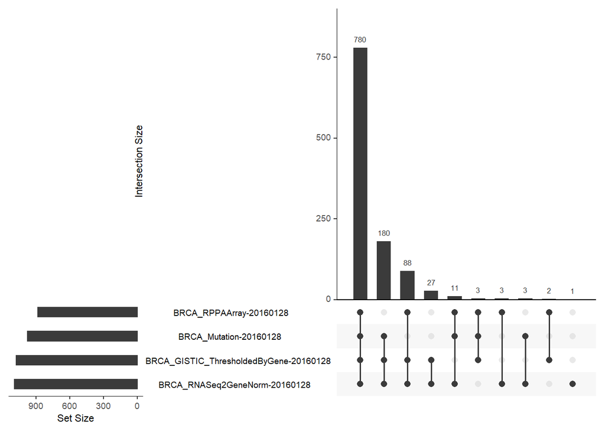

```r
upsetSamples(BRCAmae)
```

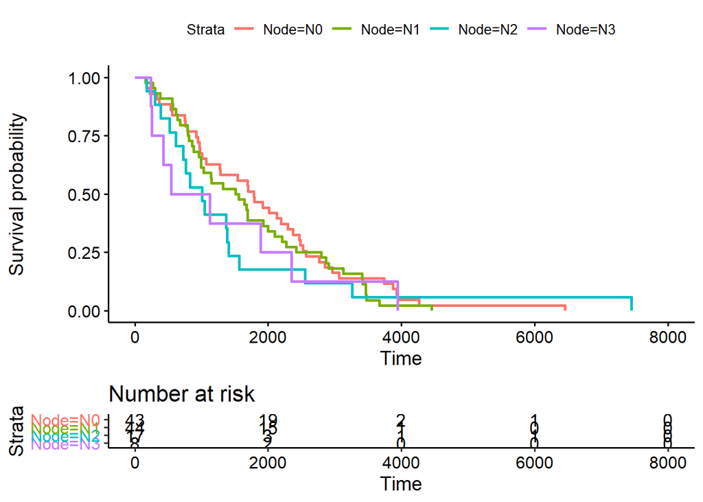

```r
BRCAmaesurv <- BRCAmae[, complete.cases(BRCAmae$days_to_death, BRCAmae$vital_status), ]


fit <- survfit(Surv(days_to_death, vital_status)~Node, data = colData(BRCAmaesurv))
ggsurvplot(fit, data = colData(BRCAmaesurv), risk.table = T)
```

In this step, we will clean, reshape, and normalize the data if needed for further analysis.

```r
## col_data for graph annotation
dfcolData <- data.frame(matrix(nrow = nrow(colData(BRCAmae))))
for(i in 1:ncol(colData(BRCAmae))){dfcolData <- cbind(dfcolData, BRCAmae@colData@listData[i])}
dfcolData <- dfcolData[,-1]
rownames(dfcolData) <- BRCAmae@colData@rownames
colnames(dfcolData) <- gsub("\\-|\\_", ".", colnames(dfcolData))
rownames(dfcolData) <- gsub("\\-|\\_", ".", rownames(dfcolData))

toBeRemoved <- which(data.frame(map(dfcolData, ~sum(is.na(.))))> nrow(dfcolData)*0.3)# just to reduce the dimension, not for imputing
dfcolData <- dfcolData[,-(toBeRemoved)]

# select patients with only ductal or lobular carcinoma
 dfcolData <- dfcolData %>% filter(histological.type == "infiltrating ductal carcinoma" | histological.type == "infiltrating lobular carcinoma")


######
listAssays <- assays(BRCAmae)

#######
## RNA-Seq
RNASeq <- listAssays[[3]]
colnames(RNASeq) <- gsub("(\\-[[:alnum:]]+\\-[[:alnum:]]+\\-[[:alnum:]]+\\-[0-9]+)$", "", colnames(RNASeq))
# log transformation
RNASeq <- log2(RNASeq +1)

dim(RNASeq)
```

```
## [1] 20501  1212
```